# Comparison of clusters

# 1 Analysis

Create pagoda object for raw data:

```
## 3441 cells, 8152 genes; normalizing ... using plain model winsorizing ... done.
## calculating distance ... done
```

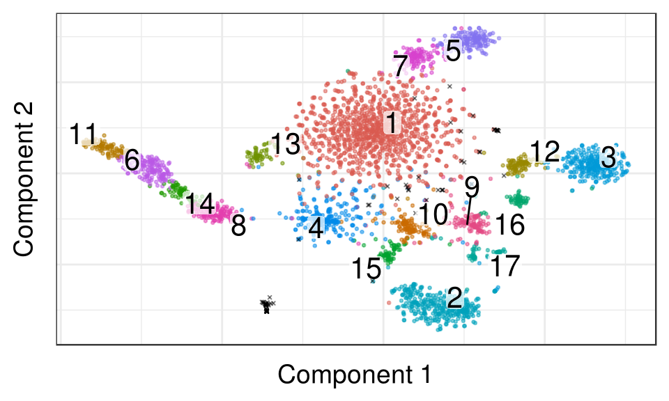

## 1.1 Magnitude of correction

Raw expression:

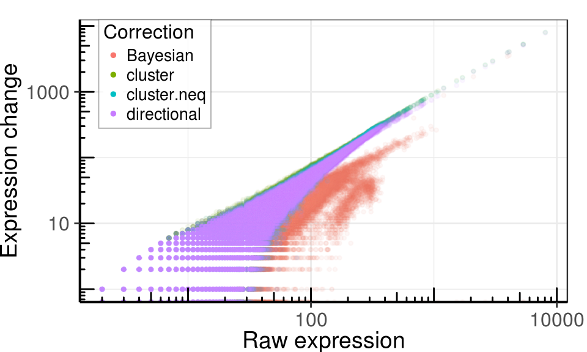

Normalized expression:

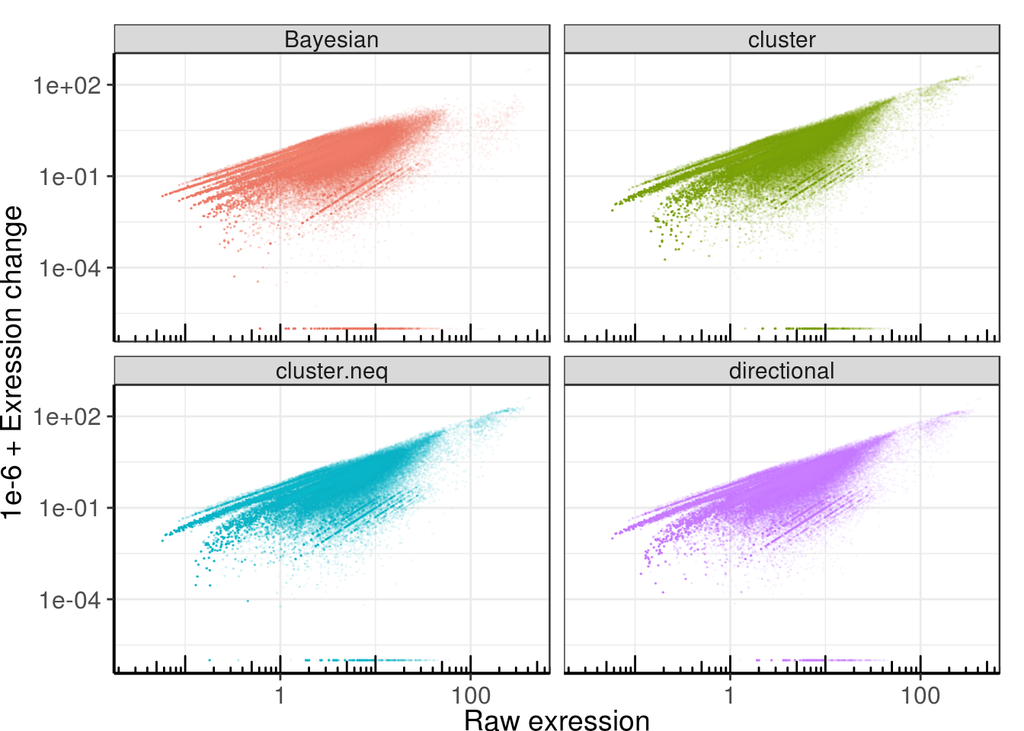

## 1.2 Target correlations

Let’s pick genes with large correction (above 20%), which are expressed in at least half of cells in cluster. These genes are selected separately for each cluster.

Correlation change accumulated by all clusters:

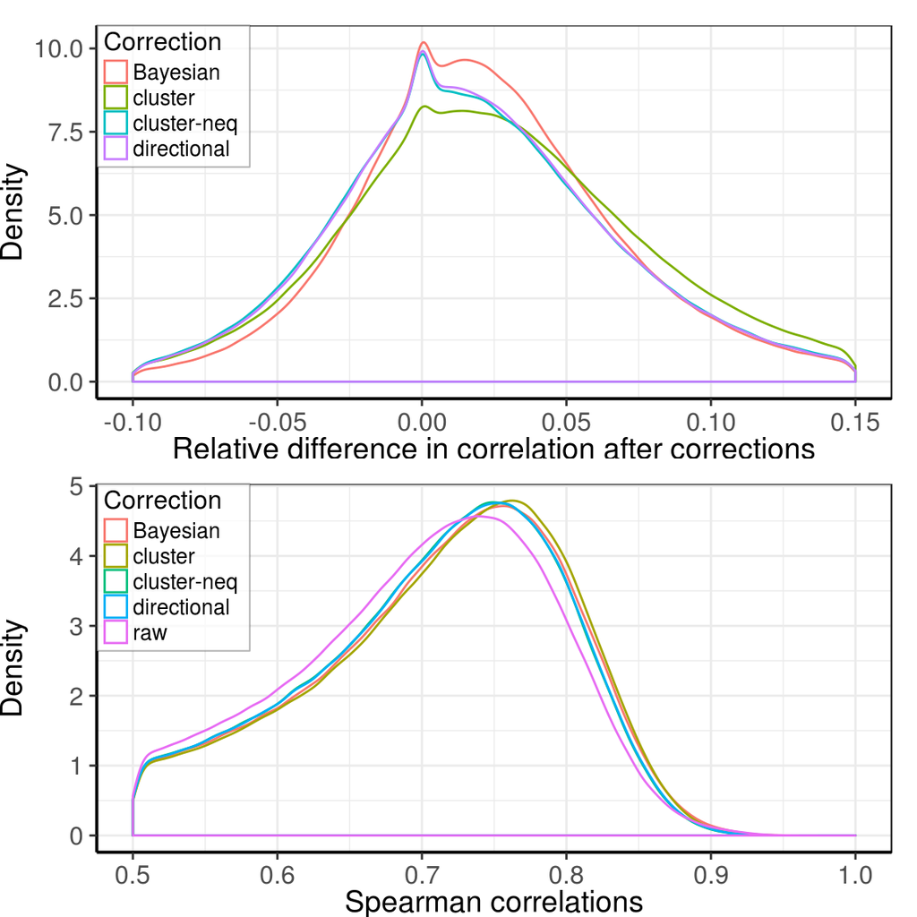

Correlation distribution by each cluster (just to ensure that nothing weird happens):

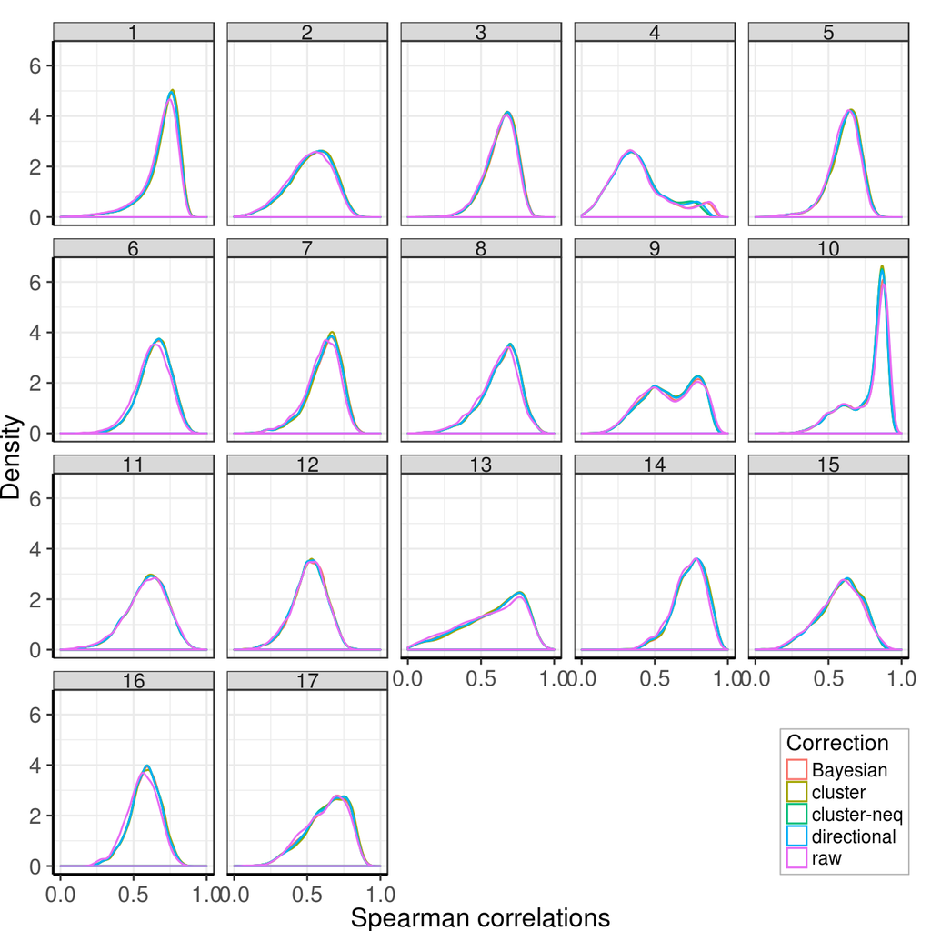

### 1.2.1 Analysis

To understand the reason of the difference between correlations, we can look at a fixe pair of cells. To present these pairs we can plot heatmap, which would be the graphical representation of the contingency table for these cells. Numbers above the plots denote Spearman correlation. Here, all expression values above the x/y border were set to the border value.

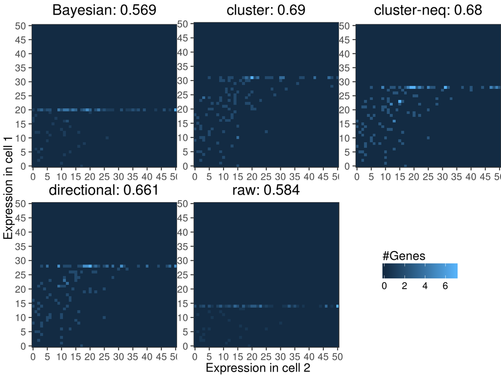

### 1.2.2 Filtration of lowly expressed genes

Let’s use another filtration criteria. Now we pick only genes with correction above 5% and with trimmed mean (level 10%) of non-normalized expression level above 10.

Number of genes per cluster:

```
##  1  2  3  4  5  6  7  8  9 10 11 12 13 14 15 16 17
## 43 17 33 91 22 10 22 32 90 98  7  9  9 10 55 21 82
```

Let’s remove all clusters with less than 80 genes.

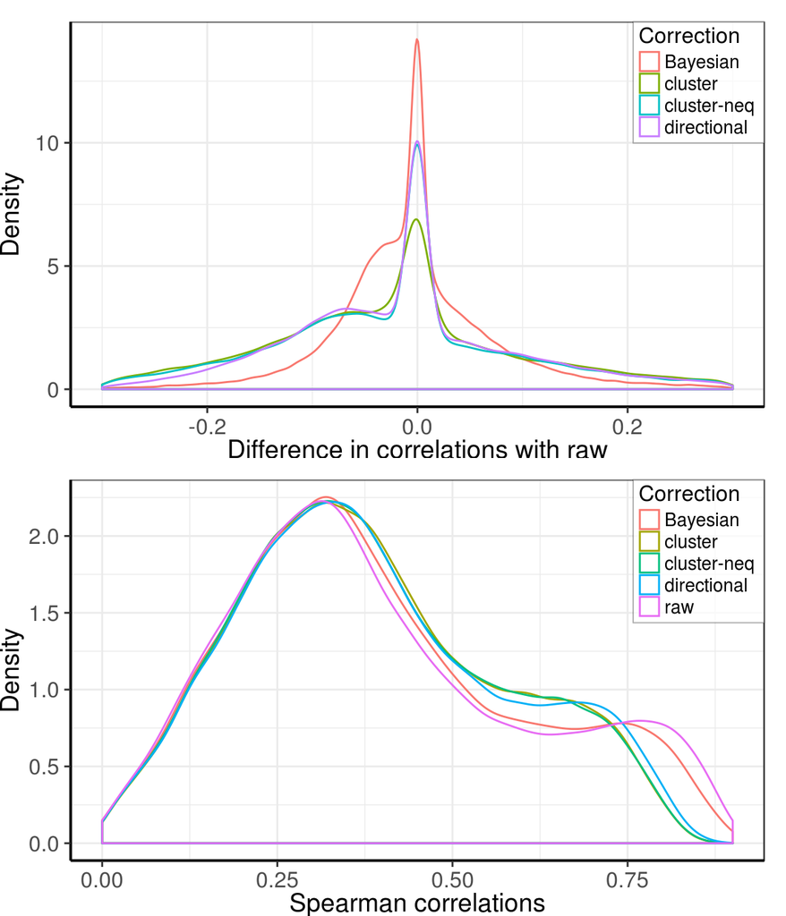

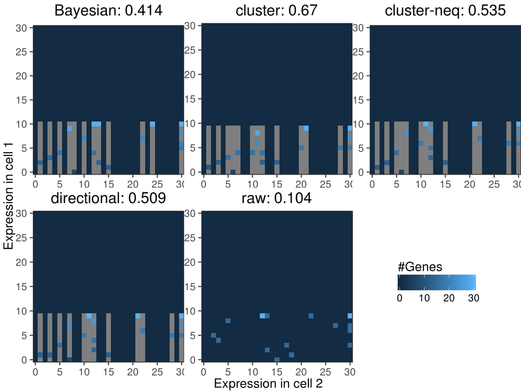

These results looks too weird to rely on them.

## 1.3 Variation

Variation of a single gene expression within fixed cluster (after normalization) is another possible measure. It allows us to increase gene filtration thresholds, as now we analyze single genes, but not gene vectors. Here we used only genes with the correction size > 10% and median normalized expression > 10.

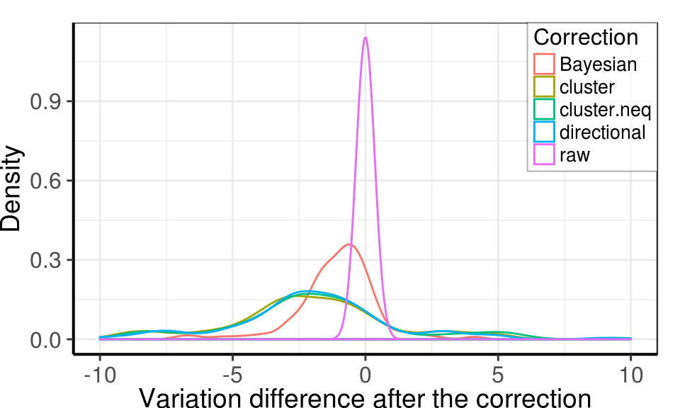

Dependency between mean and variation:

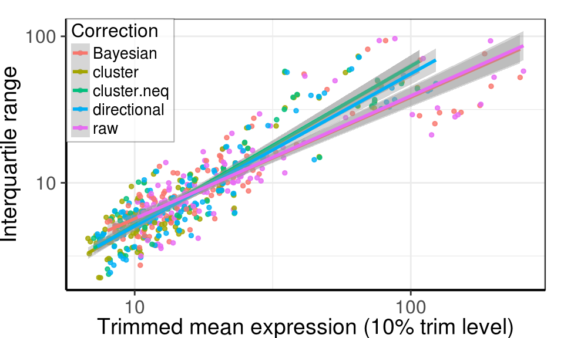

According to this plot, `cluster` and `directional` corrections increase variation coeffitient.

## 1.4 Difference between clusters

Another measure is ability to distinguish differentially expressed genes. To fild highly expressed genes we estimated mean normalized gene expression level within each cluster (10% trimmed mean was used). Genes with me expression > 5 for at least one cluster were considered as highly-expressed.

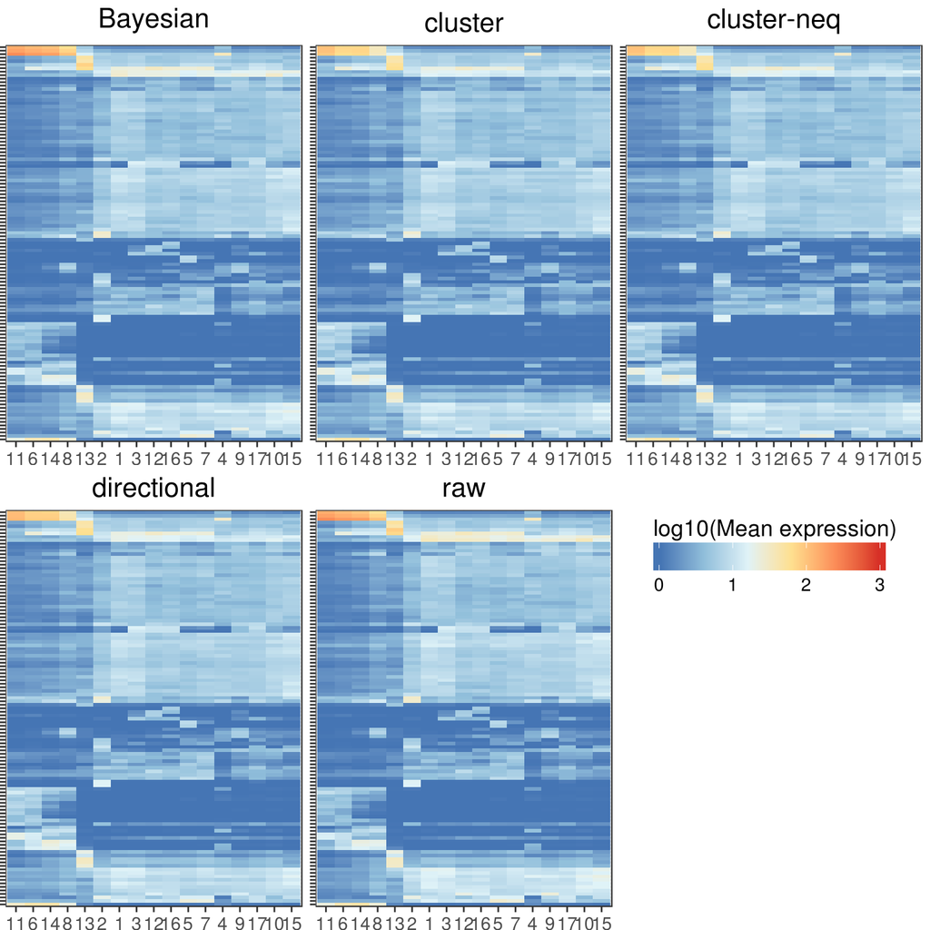

We can see that a lot of clusters has the same set of highly-expressed genes. Let’s choose some such genes and clusters.

Genes:

```
##  [1] "ENSG00000100316" "ENSG00000122026" "ENSG00000149273"
##  [4] "ENSG00000198034" "ENSG00000112306" "ENSG00000089009"
##  [7] "ENSG00000186468" "ENSG00000161970" "ENSG00000108298"
## [10] "ENSG00000142676" "ENSG00000144713" "ENSG00000105640"
## [13] "ENSG00000164587" "ENSG00000197958" "ENSG00000105372"
## [16] "ENSG00000137818" "ENSG00000087086"
```

Clusters:

```
##  [1]  1  3 12 16  5  7  4  9 17 10 15
```

Dependency between 10% trimmed mean and interquartile range for data, aggreagted by genes and clusters:

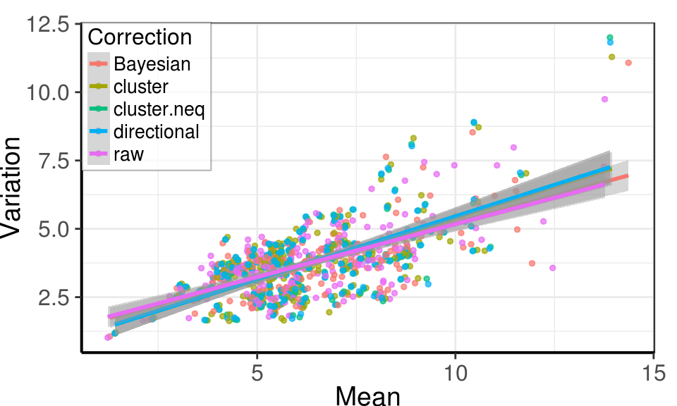

This plot is quite similar to the previous one of this type.  
Here is the same plot by genes, expression is averaged by cells within each cluster:

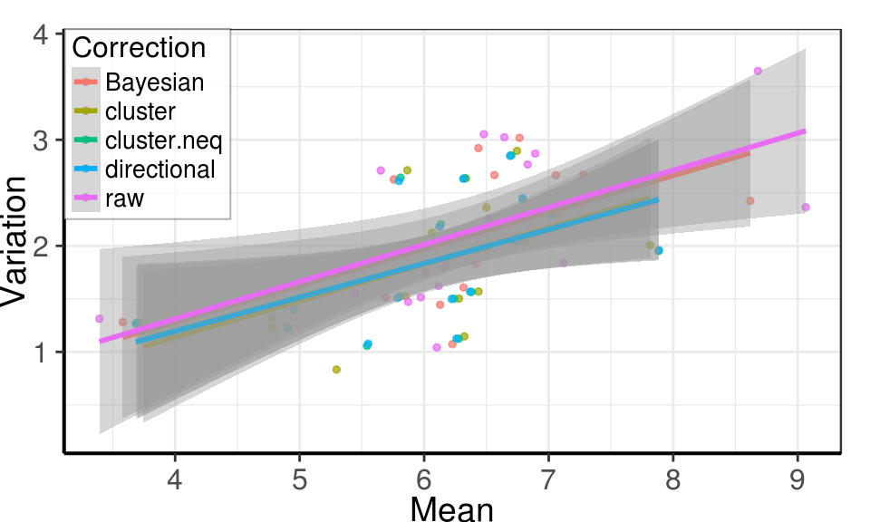

These lines have almost the same slope. Thus, no difference can be shown.

## 1.5 Edit distances

Comparison of edit distances with the expected distribution, similar to UMI Tools paper.

Here, confidence intervals are negligable and not shown:

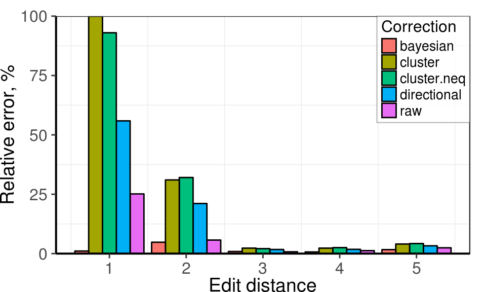